# Advanced Topic Instructions

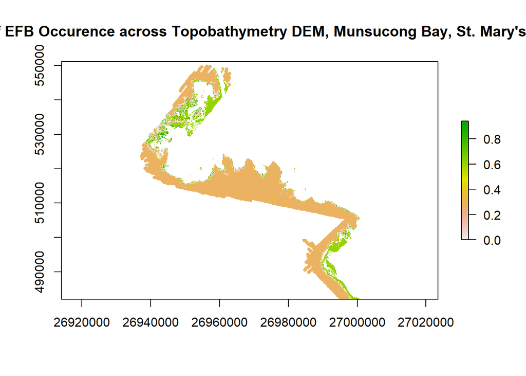

```r
erf <- evaluate(pres_test,abs_test,rf1)
#Without spatial blocking, AUC is slightly improved to 0.62.

#now let's plot RF predictions across the entire raster
prf <- raster::predict(topobath, rf1, progress='text')
plot(prf, main= "Probability of EFB Occurence across Topobathymetry DEM, Munsucong Bay, St. Mary's River, MI")
```

[output not shown]

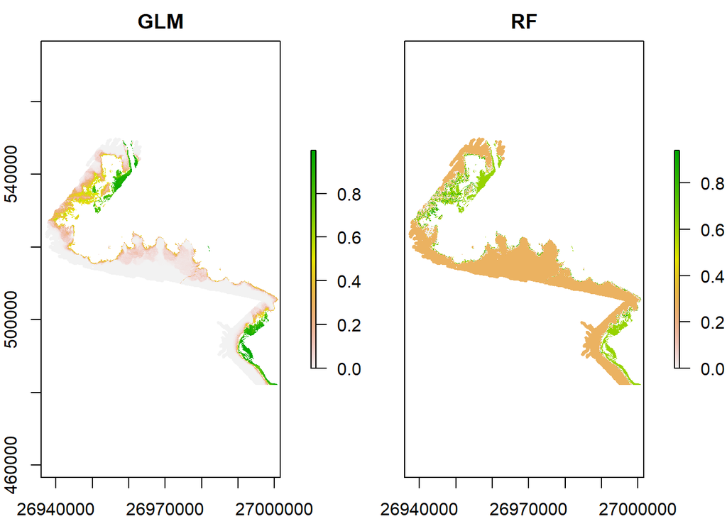

```r
#EFB's habitat suitability from rf predictions look quite different from the glm! Lastly, we can plot individual outputs and compare side by side, and also average the model ouputs and plot EFB habitat suitability.
models <- stack(p2, prf)
names(models) <- c("GLM", "RF")
plot(models)
```

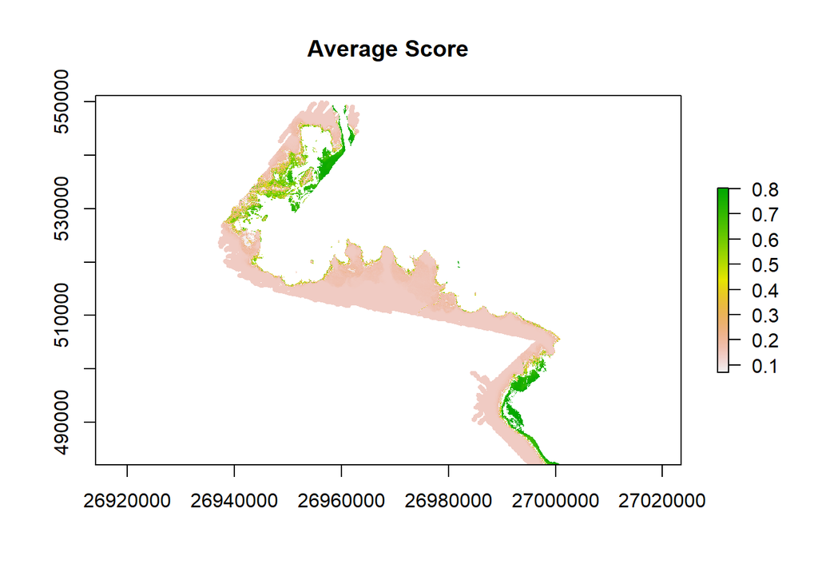

```r
#Compare side by side

#average predictions
m <- mean(models)
plot(m, main= "Average Score")
```

## Introduce the packages Given your psuedo code, where is the critical step? What packages and functions are you considering to help you complete this step? Why did you choose them? The critical steps here were to reorganize the dataset into an analyzable format (survey plots as rows, with species occurence/ predictors variables as columns) which I was able to accomplish with tidyr. Also, I needed to subset the entire field dataset to the county where the topobathymetry layer is located, with base r. I then needed to convert this dataset into a SpatialPoints dataframe and assign it’s CRS to that of the DEM. Lastly, I needed to extract values from the raster and then use these as predictors for my occurrence points in the models. Lastly, raster::predict allowed me to predict the probability of EFB occruence across all cells of the raster based on the estimates from the model outputs.

## Evaluate your choices

Use profiling and benchmarking to evaluate which of your options is likely to be the fastest. How does the syntax and/or ease of use of that function impact your decision of whether or not to use it? (For example, velox is much faster than raster, but it’s less well documented and the syntax is strange to get used to). Chunk 8!

## Show us your final product

Did you make a map? Let’s see it. Did you plot some data that you extracted with raster? show us that plot. Did you have an idea of how the data should look after you were done processing it? Were you successful? What went wrong Chunk 7 for extracted topobathymetry values, and Chunks 9-11 for somewhat informative maps!

## Reflect

Write a few sentences on what you learned from this exercise. How has your skill improved? What do you wish you understood better? What do you imagine your next steps to be? I’ve learned that there are many ways to model and predict the distribution of a species! I’ve also learned that a spatially unbiased field data set of occurence is likely key for me to most optimally predict the distribution of EFB. Since my dataset and predictors is fairly spatially biased, I have learned that there are ways to reduce those biases in my training and testing datasets to obtain better estimates of predictors in whatever modeling approach I use. I also learn that scale matters. This topobathymetry layer I used for this project is on the scale of feet, whereas EFB’s true distribution may vary more on the scale of cm within and across the wetland vegetation zones. Lastly, like in the dismo vignette, there are likely many biophysical and anthropogenic factors that contribute to EFB’s distribution in MI! If available, I should consider radar rasters (for emergent vegetation) and other geospatial datasets (e.g. nutrient levels) to incluede in my SDM framework.

Once you’re done push the “knit” button to create the html page from your Rmarkdown document. If you’ve got questions, let me know!!